# Estudo sobre dados de Vinhos Tintos por Fábio Lopes

## Seção de Gráficos Univariados

Verificando algumas linhas dos dados

```
##   X fixed.acidity volatile.acidity citric.acid residual.sugar chlorides
## 1 1           7.4             0.70        0.00            1.9     0.076
## 2 2           7.8             0.88        0.00            2.6     0.098
## 3 3           7.8             0.76        0.04            2.3     0.092
## 4 4          11.2             0.28        0.56            1.9     0.075
## 5 5           7.4             0.70        0.00            1.9     0.076
## 6 6           7.4             0.66        0.00            1.8     0.075
##   free.sulfur.dioxide total.sulfur.dioxide density   pH sulphates alcohol
## 1                  11                   34  0.9978 3.51      0.56     9.4
## 2                  25                   67  0.9968 3.20      0.68     9.8
## 3                  15                   54  0.9970 3.26      0.65     9.8
## 4                  17                   60  0.9980 3.16      0.58     9.8
## 5                  11                   34  0.9978 3.51      0.56     9.4
## 6                  13                   40  0.9978 3.51      0.56     9.4
##   quality
## 1       5
## 2       5
## 3       5
## 4       6
## 5       5
## 6       5
```

Existem 11 atributos que podem contribuir na qualidade do vinho. A qualidade do vinho está pontuada de 0 a 10.

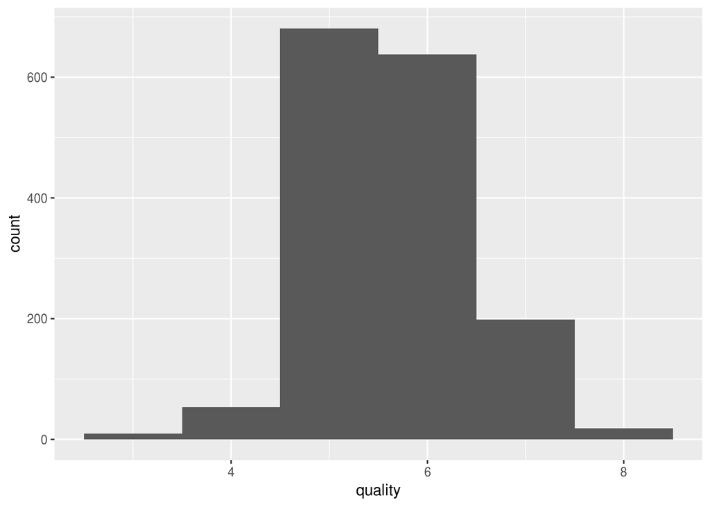

```
##    Min. 1st Qu.  Median    Mean 3rd Qu.    Max.
##   3.000   5.000   6.000   5.636   6.000   8.000
```

Pelo gráfico/resumo anterior, podemos observar que a qualidade dos vinhos observados vão de 3 a 8.

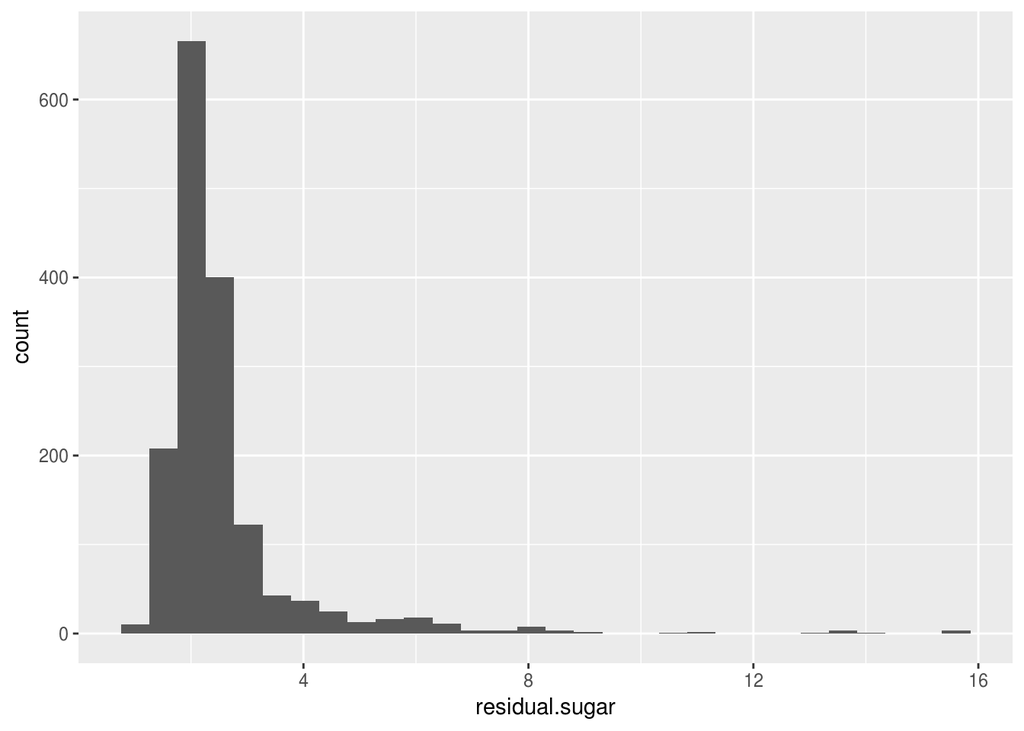

```
##    Min. 1st Qu.  Median    Mean 3rd Qu.    Max.
##   0.900   1.900   2.200   2.539   2.600  15.500
```

Os dados estão muito concentrados, vamos exibir valores de 0.1 em 0.1 e dar um zoom na região entre 0 e 4.

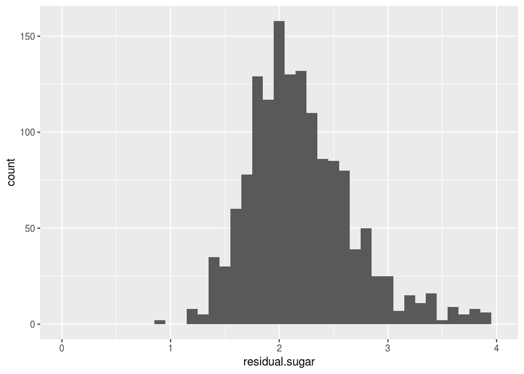

```
##    Min. 1st Qu.  Median    Mean 3rd Qu.    Max.
##   0.900   1.900   2.100   2.201   2.500   3.900
```

Podemos observar que a maioria dos valores giram em torno de 2.

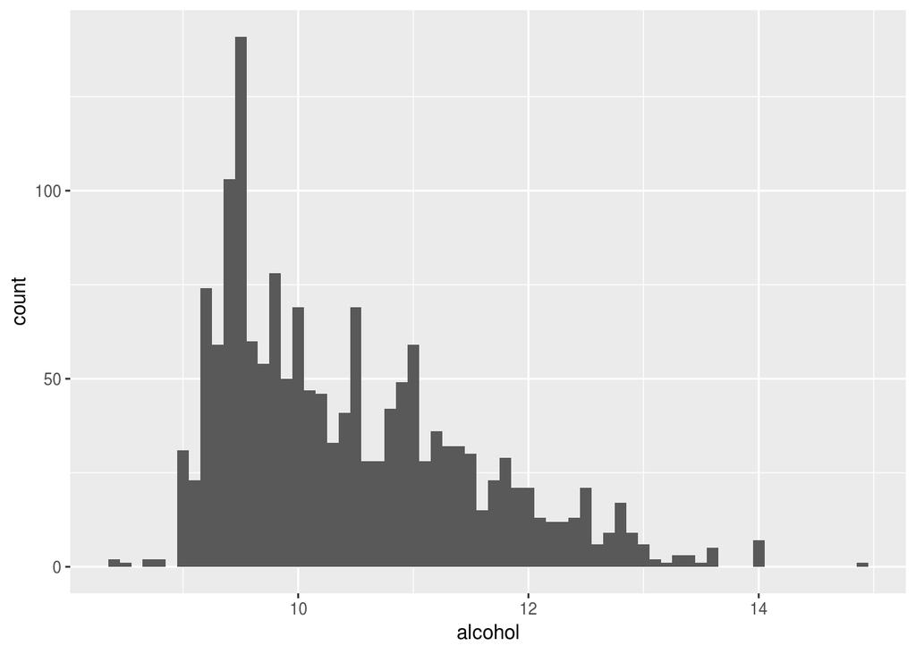

```
##    Min. 1st Qu.  Median    Mean 3rd Qu.    Max.
##    8.40    9.50   10.20   10.42   11.10   14.90
```

Olhando para o atributo alcool, vemos que existe uma concentração grande em 9.5.

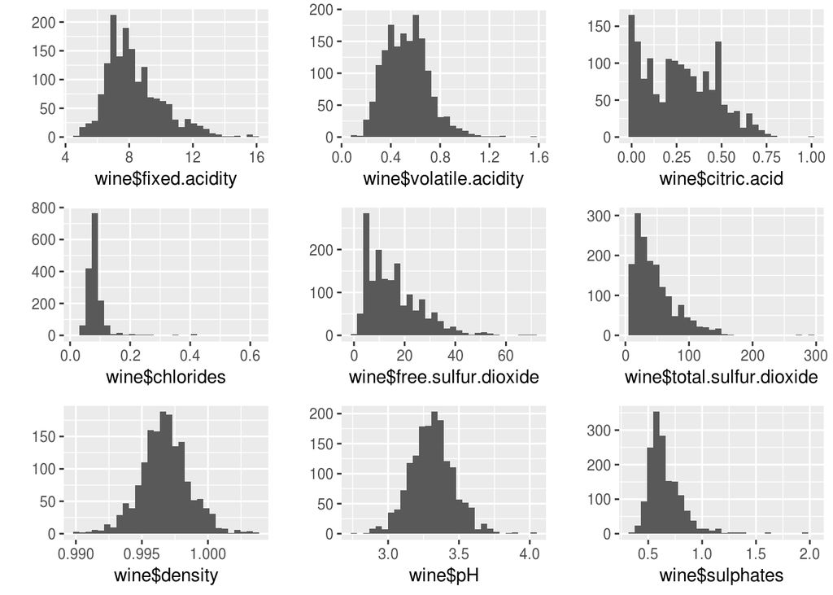

Observando os demais atributos, vamos pegar o cloreto que possui uma concentração grande em uma região, vamos utilizar log10 para mudar a escala, pois os dados parecem estar bem agrupados.

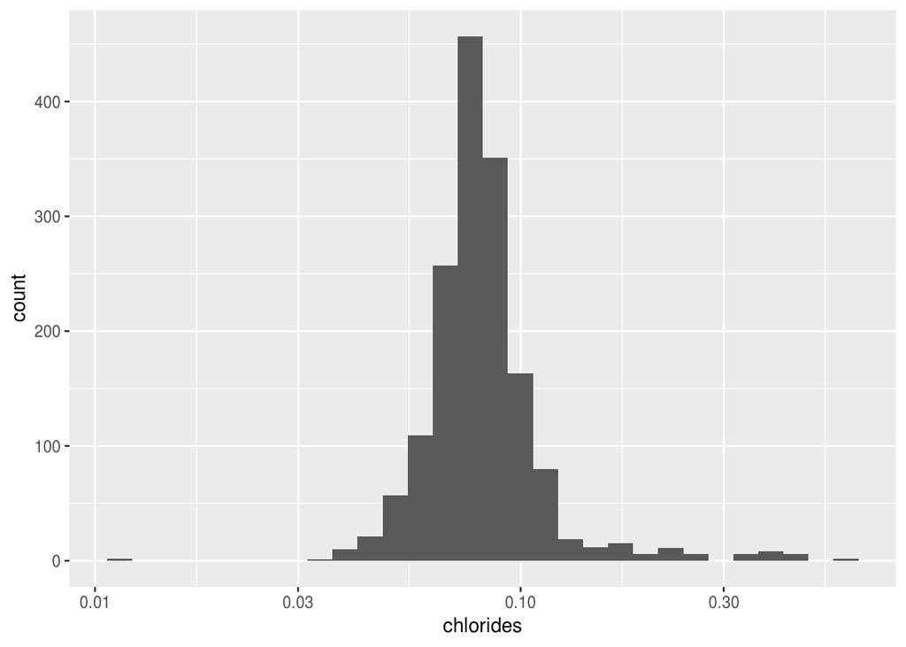

```
##    Min. 1st Qu.  Median    Mean 3rd Qu.    Max.
## 0.01200 0.07000 0.07900 0.08747 0.09000 0.61100
```

Vamos ver o ácido cítrico com um binwidth bem pequeno.

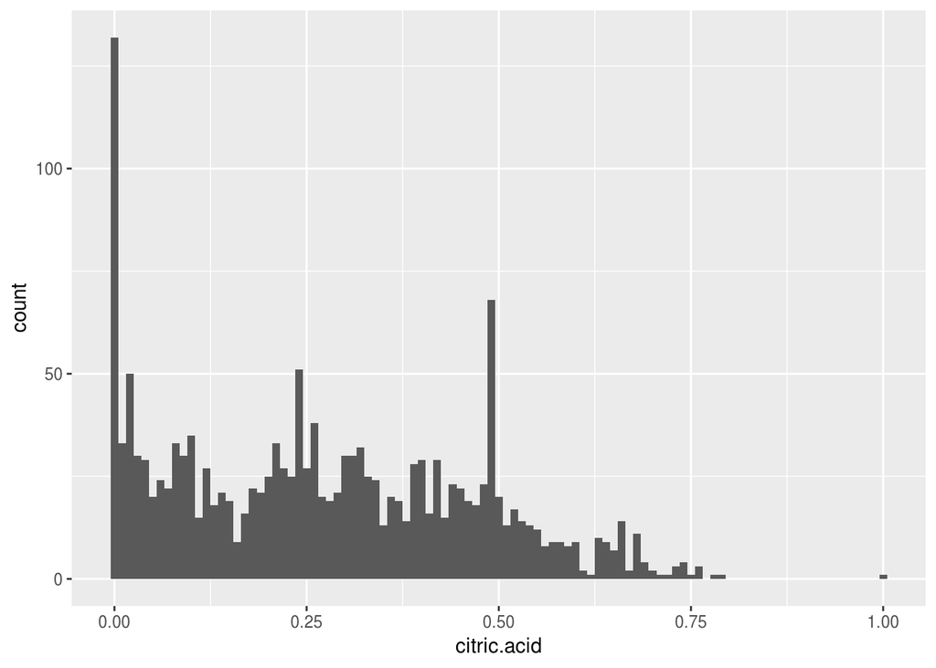

```
##    Min. 1st Qu.  Median    Mean 3rd Qu.    Max.
##   0.000   0.090   0.260   0.271   0.420   1.000
```

Agora vamos olhar a densidade que aparentemente parecem estar distribuídas de forma normal.

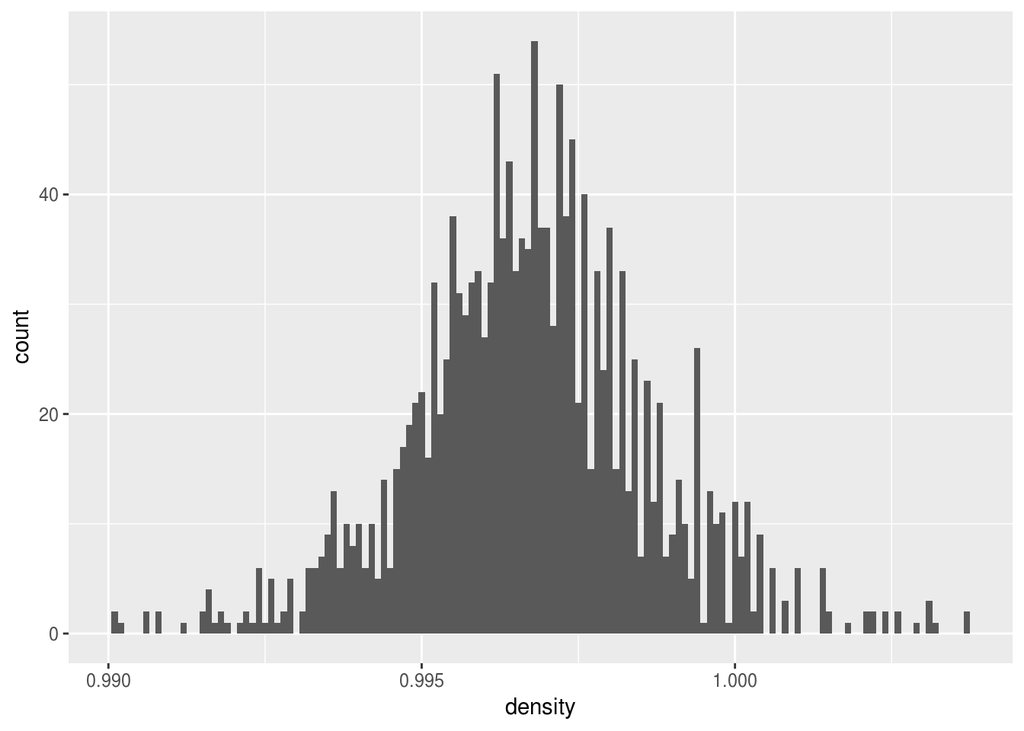

```
##    Min. 1st Qu.  Median    Mean 3rd Qu.    Max.
##  0.9901  0.9956  0.9968  0.9967  0.9978  1.0040
```

## Análise Univariada

### Quais são os principais atributos de interesse deste conjunto de dados?

Estou interessado no atributo qualidade e em como os demais atributos podem afetar. A qualidade está entre 0 e 10, porém no conjunto de dados só temos observações entre 3 e 8.

### Quais outros atributos você acha que podem lhe auxiliar na investigação destes atributos de interesse?

Acredito que a acidez, o ácido cítrico, o açucar ou os cloretos podem influenciar na qualidade. Vamos aguardar as análises futuras para comprovar ou não.

### Você criou novas variáveis a partir dos atributos existentes no conjunto de dados?

Não.

### Dos atributos investigados, distribuições incomuns foram encontradas? Você aplicou operações nos dados para limpá-los, ajustá-los ou mudar a forma dos dados? Se sim, por quê?

Sim, no cloreto. Ajustei com a escala log10 para poder visualizar melhor os valores, pois estavam muito concentrados em uma região.

## Seção de Gráficos Bivariados

```
##                           X fixed.acidity volatile.acidity citric.acid
## X                     1.000        -0.268           -0.009      -0.154
## fixed.acidity        -0.268         1.000           -0.256       0.672
## volatile.acidity     -0.009        -0.256            1.000      -0.552
## citric.acid          -0.154         0.672           -0.552       1.000
## residual.sugar       -0.031         0.115            0.002       0.144
## chlorides            -0.120         0.094            0.061       0.204
## free.sulfur.dioxide   0.090        -0.154           -0.011      -0.061
## total.sulfur.dioxide -0.118        -0.113            0.076       0.036
## density              -0.368         0.668            0.022       0.365
## pH                    0.136        -0.683            0.235      -0.542
## sulphates            -0.125         0.183           -0.261       0.313
## alcohol               0.245        -0.062           -0.202       0.110
## quality               0.066         0.124           -0.391       0.226
##                      residual.sugar chlorides free.sulfur.dioxide
## X                            -0.031    -0.120               0.090
## fixed.acidity                 0.115     0.094              -0.154
## volatile.acidity              0.002     0.061              -0.011
## citric.acid                   0.144     0.204              -0.061
## residual.sugar                1.000     0.056               0.187
## chlorides                     0.056     1.000               0.006
## free.sulfur.dioxide           0.187     0.006               1.000
## total.sulfur.dioxide          0.203     0.047               0.668
## density                       0.355     0.201              -0.022
## pH                           -0.086    -0.265               0.070
## sulphates                     0.006     0.371               0.052
## alcohol                       0.042    -0.221              -0.069
## quality                       0.014    -0.129              -0.051
##                      total.sulfur.dioxide density     pH sulphates alcohol
## X                                  -0.118  -0.368  0.136    -0.125   0.245
## fixed.acidity                      -0.113   0.668 -0.683     0.183  -0.062
## volatile.acidity                    0.076   0.022  0.235    -0.261  -0.202
## citric.acid                         0.036   0.365 -0.542     0.313   0.110
## residual.sugar                      0.203   0.355 -0.086     0.006   0.042
## chlorides                           0.047   0.201 -0.265     0.371  -0.221
## free.sulfur.dioxide                 0.668  -0.022  0.070     0.052  -0.069
## total.sulfur.dioxide                1.000   0.071 -0.066     0.043  -0.206
## density                             0.071   1.000 -0.342     0.149  -0.496
## pH                                 -0.066  -0.342  1.000    -0.197   0.206
## sulphates                           0.043   0.149 -0.197     1.000   0.094
## alcohol                            -0.206  -0.496  0.206     0.094   1.000
## quality                            -0.185  -0.175 -0.058     0.251   0.476
##                      quality
## X                      0.066
## fixed.acidity          0.124
## volatile.acidity      -0.391
## citric.acid            0.226
## residual.sugar         0.014
## chlorides             -0.129
## free.sulfur.dioxide   -0.051
## total.sulfur.dioxide  -0.185
## density               -0.175
## pH                    -0.058
## sulphates              0.251
## alcohol                0.476
## quality                1.000
```

Há muitas coisas para olhar, então vamos tentar reduzi-las antes de fazermos uma matriz de dispersão. Corremos o risco de perder alguns detalhes. Vamos considerar o ácido como um substituto para a acidez, a acidez volátil e o pH. Nós também faremos o mesmo usando sulfatos para dióxido de enxofre e dióxido de enxofre total.

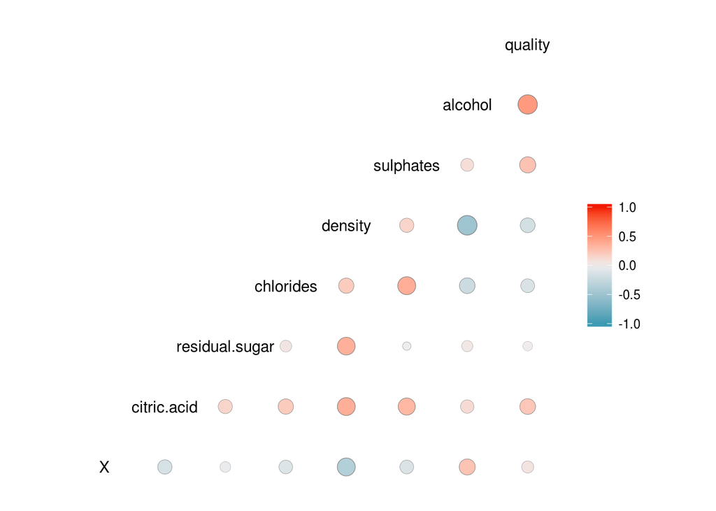

Os cloretos parecem estar relativamente correlacionados com muitas outras variáveis. Ácido cítrico, densidade, sulfatos e álcool, todos têm uma correlação coeficiente acima de 0,2 com cloretos. Como o interesse é a qualidade, vamos dar uma olhada nos itens mais correlacionados, como álcool, sulfatos e ácido cítrico.

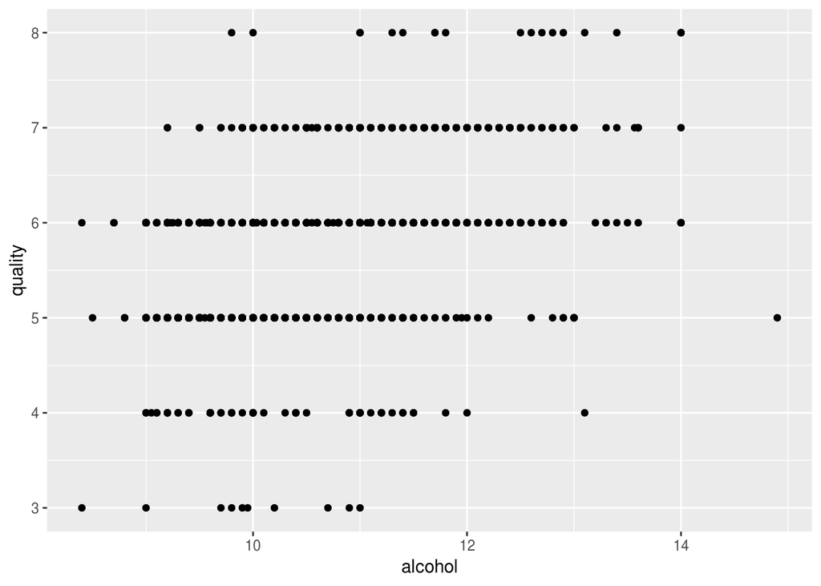

```
## wine$quality: 3
##    Min. 1st Qu.  Median    Mean 3rd Qu.    Max.
##   8.400   9.725   9.925   9.955  10.580  11.000
## --------------------------------------------------------
## wine$quality: 4
##    Min. 1st Qu.  Median    Mean 3rd Qu.    Max.
##    9.00    9.60   10.00   10.27   11.00   13.10
## --------------------------------------------------------
## wine$quality: 5
##    Min. 1st Qu.  Median    Mean 3rd Qu.    Max.
##     8.5     9.4     9.7     9.9    10.2    14.9
## --------------------------------------------------------
## wine$quality: 6
##    Min. 1st Qu.  Median    Mean 3rd Qu.    Max.
##    8.40    9.80   10.50   10.63   11.30   14.00
## --------------------------------------------------------
## wine$quality: 7
##    Min. 1st Qu.  Median    Mean 3rd Qu.    Max.
##    9.20   10.80   11.50   11.47   12.10   14.00
## --------------------------------------------------------
## wine$quality: 8
##    Min. 1st Qu.  Median    Mean 3rd Qu.    Max.
##    9.80   11.32   12.15   12.09   12.88   14.00
```

Isso é difícil de ver porque muitos pontos estão provavelmente um em cima do outro. Vamos adicionar um pouco de jitter e uma linha de tendência.

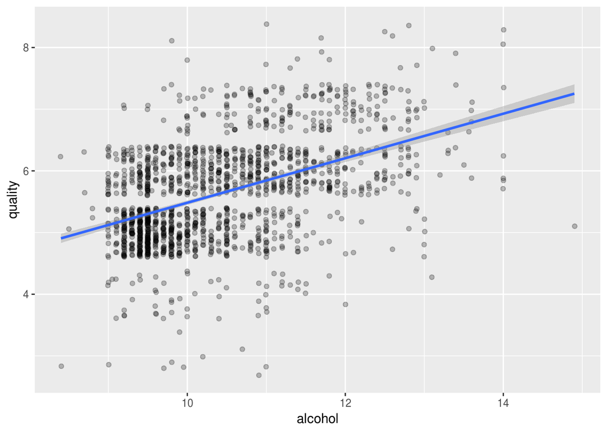

```
## wine$quality: 3
##    Min. 1st Qu.  Median    Mean 3rd Qu.    Max.
##   8.400   9.725   9.925   9.955  10.580  11.000
## --------------------------------------------------------
## wine$quality: 4
##    Min. 1st Qu.  Median    Mean 3rd Qu.    Max.
##    9.00    9.60   10.00   10.27   11.00   13.10
## --------------------------------------------------------
## wine$quality: 5
##    Min. 1st Qu.  Median    Mean 3rd Qu.    Max.
##     8.5     9.4     9.7     9.9    10.2    14.9
## --------------------------------------------------------
## wine$quality: 6
##    Min. 1st Qu.  Median    Mean 3rd Qu.    Max.
##    8.40    9.80   10.50   10.63   11.30   14.00
## --------------------------------------------------------
## wine$quality: 7
##    Min. 1st Qu.  Median    Mean 3rd Qu.    Max.
##    9.20   10.80   11.50   11.47   12.10   14.00
## --------------------------------------------------------
## wine$quality: 8
##    Min. 1st Qu.  Median    Mean 3rd Qu.    Max.
##    9.80   11.32   12.15   12.09   12.88   14.00
```

Parece haver uma forma geral “acima e à direita” dos pontos, mas há muitas observações em torno de 9,5% de álcool que podem estar afetando a correlação.

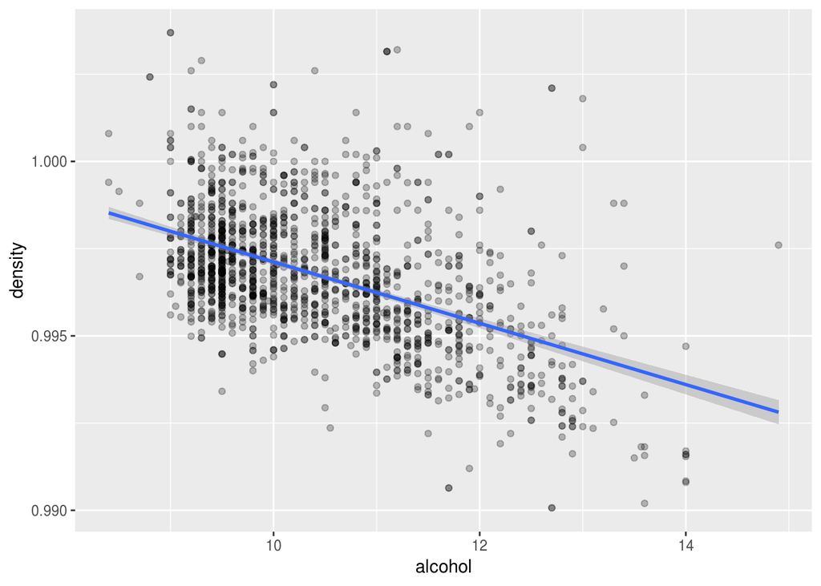

[output not shown]

[output cut: 1688 more lines]

[output not shown]

Isso parece ter um relacionamento mais forte do que o álcool e a qualidade, embora os coeficientes de correlação não sejam tão diferentes.

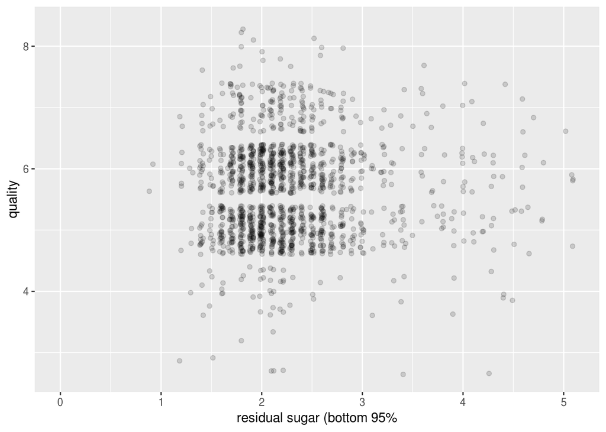

```
## wine$quality: 3
##    Min. 1st Qu.  Median    Mean 3rd Qu.    Max.
##   1.200   1.875   2.100   2.635   3.100   5.700
## --------------------------------------------------------
## wine$quality: 4
##    Min. 1st Qu.  Median    Mean 3rd Qu.    Max.
##   1.300   1.900   2.100   2.694   2.800  12.900
## --------------------------------------------------------
## wine$quality: 5
##    Min. 1st Qu.  Median    Mean 3rd Qu.    Max.
##   1.200   1.900   2.200   2.529   2.600  15.500
## --------------------------------------------------------
## wine$quality: 6
##    Min. 1st Qu.  Median    Mean 3rd Qu.    Max.
##   0.900   1.900   2.200   2.477   2.500  15.400
## --------------------------------------------------------
## wine$quality: 7
##    Min. 1st Qu.  Median    Mean 3rd Qu.    Max.
##   1.200   2.000   2.300   2.721   2.750   8.900
## --------------------------------------------------------
## wine$quality: 8
##    Min. 1st Qu.  Median    Mean 3rd Qu.    Max.
##   1.400   1.800   2.100   2.578   2.600   6.400
```

Não há realmente nenhum relacionamento aqui. A maioria dos vinhos tinha apenas cerca de 2 g / L de açúcar, e os maiores valores de açúcar são distribuídos entre as qualidades esperadas.

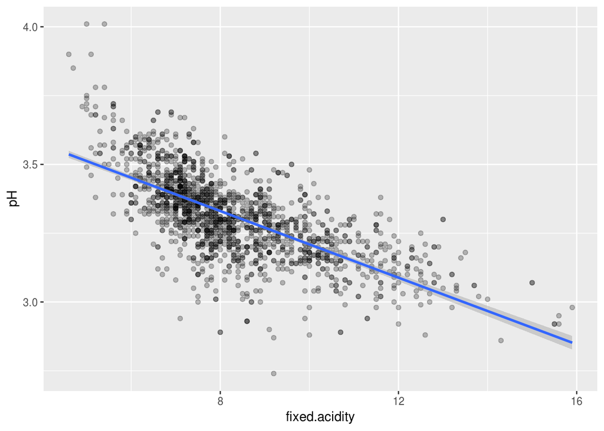

[output not shown]

[output cut: 300 more lines]

[output not shown]

Aqui é importante lembrar que os valores de pH mais baixos significam mais ácidos. Existe uma tendência ali. Quanto mais acidez houver, mais ácido o vinho é.

## Análise Bivariada

### Discuta sobre alguns dos relacionamentos observados nesta parte da investigação. Como os atributos de interesse variaram no conjunto de dados?

O açucar não influencia na qualidade do vinho. Também pensei que o teor alcoolico influenciace no indice de qualidade.

### Qual foi o relacionamento mais forte encontrado?

O relacionamento mais forte era fácil de adivinhar. O pH e a acidez foram correlacionados e tenho certeza de que adicionar a acidez volátil e o ácido cítrico teriam explicado grande parte da variação do pH.

## Seção de Gráficos Multivariados

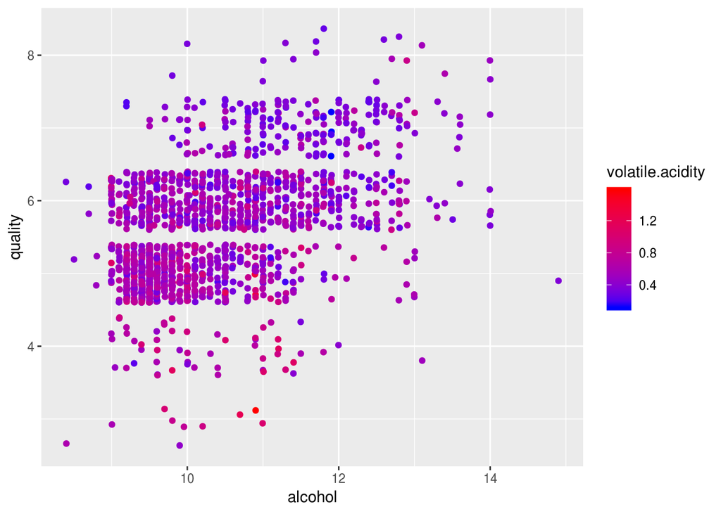

Eu tentei fazer as cores distintas aqui e ainda não consigo ver um padrão claro.

Talvez o ácido cítrico e o álcool juntos possam prever a qualidade.

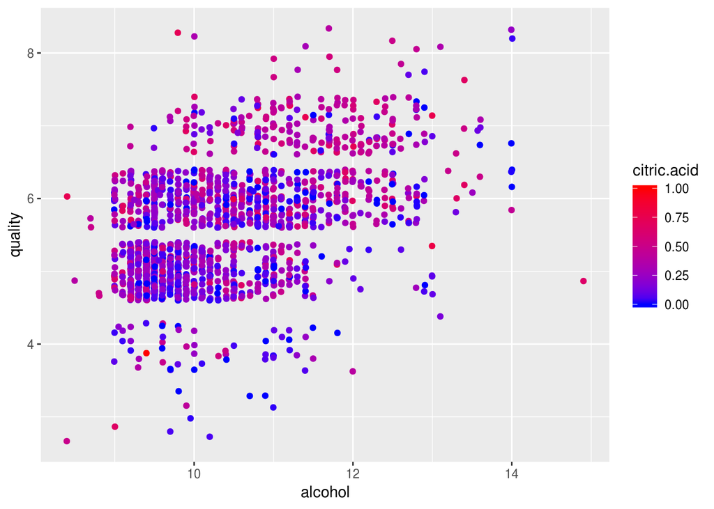

Há um pouco de padrão onde os pontos ficam mais vermelhos a direita, mas não parece muito com um padrão.

Nesse ponto, acho que selecionar as duas variáveis com os maiores coeficientes de correlação pode revelar algo.

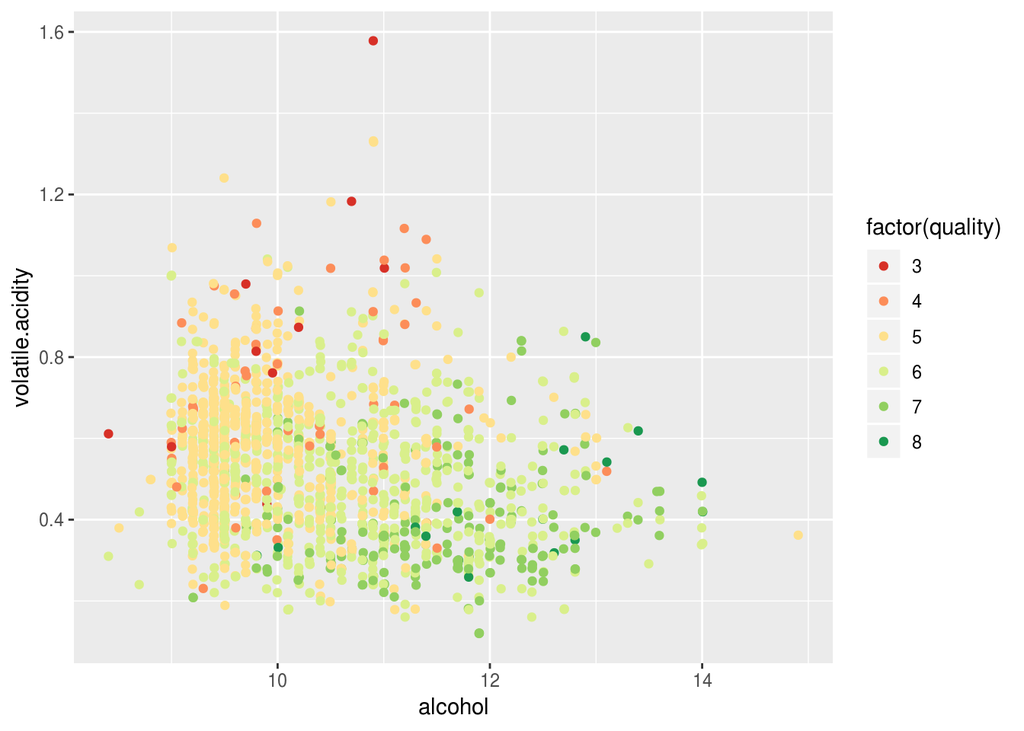

Aqui aparece um padrão, mas não acho que acrescente mais alguma informação. Nós já sabíamos que mais álcool e menos acidez volátil faziam melhor vinho, mas pelo menos isso mostra que essas duas coisas não funcionam umas contra as outras.

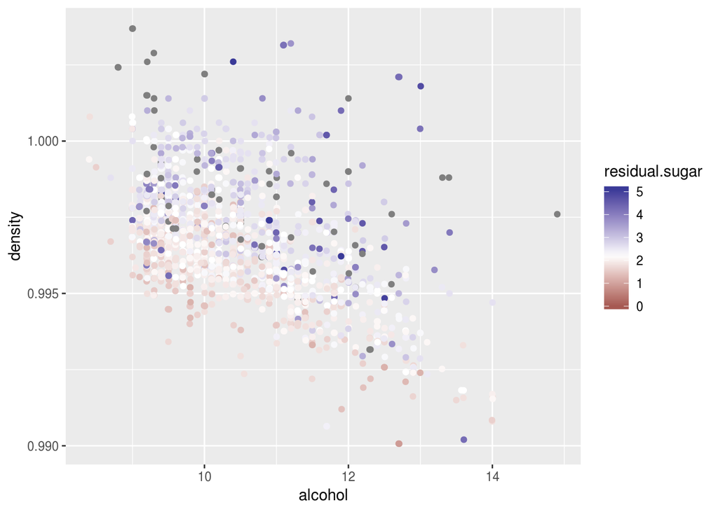

## Análise Multivariada

### Interações surpreendentes e/ou interessantes foram encontradas entre os atributos?

Não

### Modelos foram criados usando este conjunto de dados? Discuta sobre os pontos fortes e as limitações do seu modelo.

Não

## Gráficos Finais e Sumário

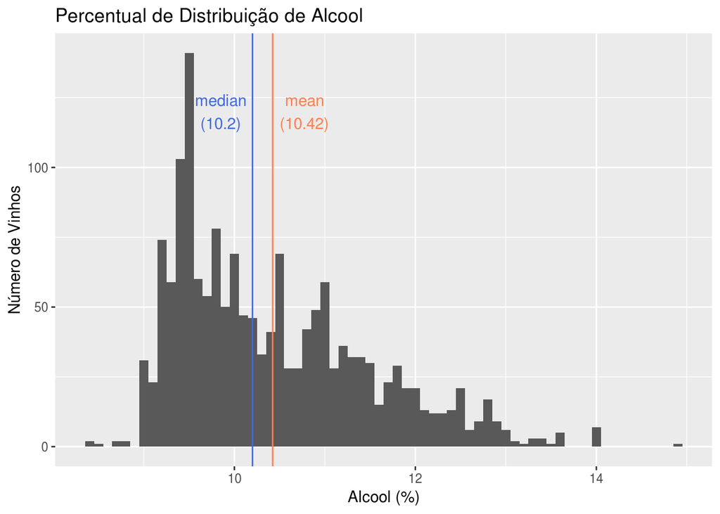

Não temos muitas observações acima de 12% de alcool. Com isso temos que levar em consideração quando analisamos a relação do alcool com a qualidade dos vinhos.

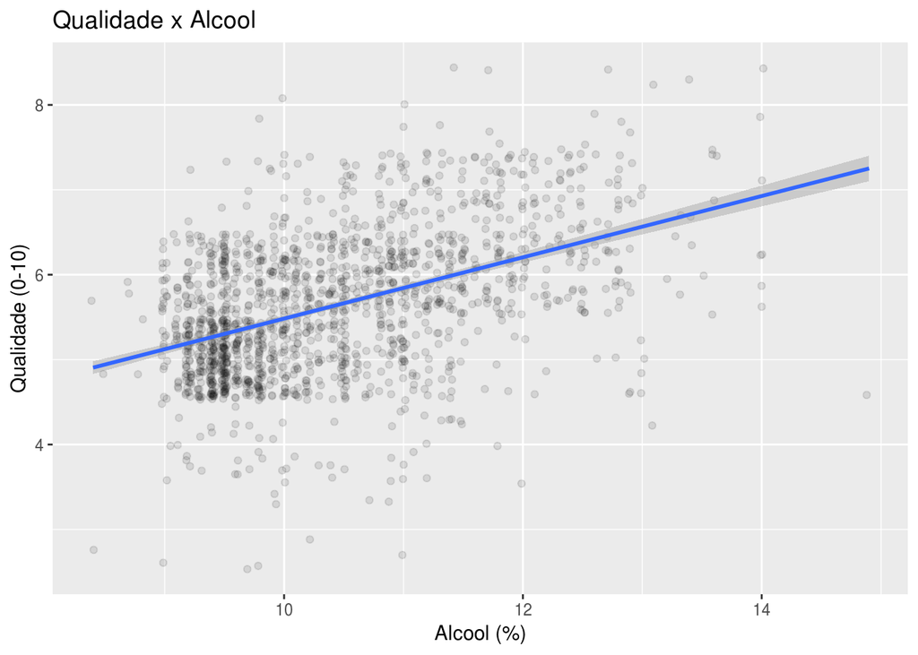

Observamos que quanto mais alcool, mais aumenta a qualidade do vinho. Porém seria interessante ter mais observações com vinhos com mais alcool para poder confirmar.

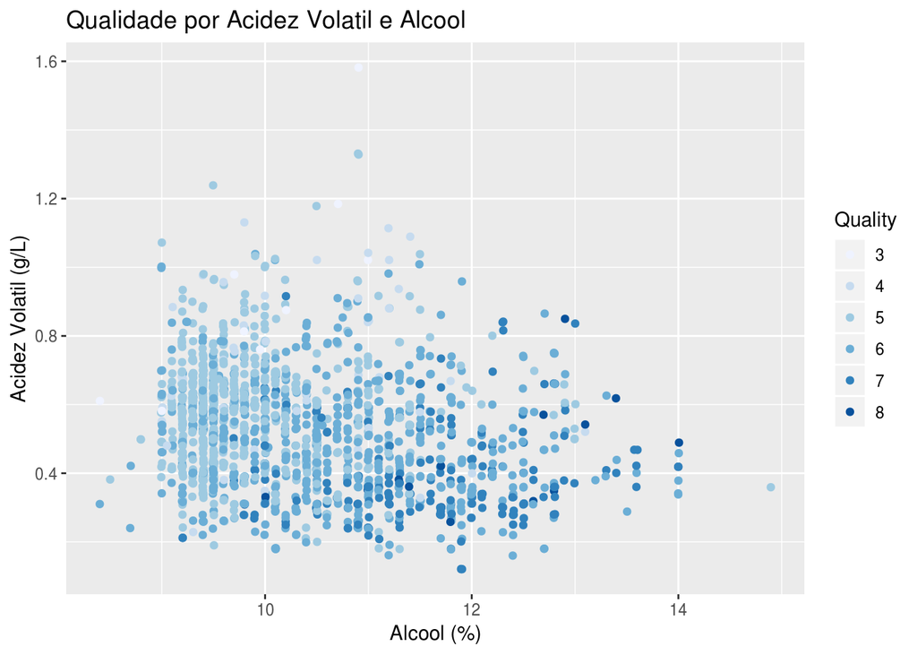

Este gráfico mostra como a qualidade melhora à medida que o teor alcoólico aumenta e a acidez volátil diminui. Há uma tendência geral de as cores ficarem mais escuras à medida que vão para o canto inferior direito.

## Reflexão

Este conjunto de dados tem 11 propriedades de 1599 vinhos tintos. Depois de examinar as distribuições de algumas variáveis, examinei a relação entre duas e, eventualmente, combinações de três variáveis.

A distribuição mais inesperada que vi foi o ácido cítrico. Ele teve o maior pico em torno de 0 e meio, mas aumentou em torno de 0,24 e 0,49 g / L. Olhando as informações do conjunto de dados, não consegui encontrar um bom motivo para essa distribuição. Pode ter algo a ver com o tipo de vinho tinto que eles usaram. Seria interessante investigar mais.

A seção de análise multivariada foi a mais difícil para mim. Eu não tinha certeza de quais variáveis poderiam ajudar para prever a qualidade. Acho que o melhor que consegui encontrar foi um par de propriedade que não tinha relação uma com a outras. A acidez volátil e o álcool foram os dois atributos com as maiores correlações e, quando trabalham juntos, há uma clara tendência na qualidade.

Para melhorar a analise no futuro, poderia colher mais dados de vinhos de baixa e alta qualidade. Percebi que o conjunto de dados é desproporcional, ou seja, existe muitos dados para vinhos de qualidade entre 5 e 6, porém para baixo (entre 3 e 4) e alta qualidade (entre 7 e 8) existem menos dados. Se o conjunto de dados tiver mais registros, tanto para qualidade mais baixas e para qualidades mais altas, melhoraria e muito a qualidade da análise. Podemos ter mais certeza se existe uma correlação significativa entre uma variavel e a qualidade do vinho.